# Hierarchical Clustering

Author: Nico Kuijpers  
Date: March 28, 2021

## Introduction

Hierarchical clustering is one of the machine learning algorithms that can be applied for unsupervised learning. In this notebook we give an example of how to apply agglomerative clustering on the Iris dataset.

First import the libraries we need.

```python
import numpy as np
import pandas as pd
import sklearn as sk
import seaborn as sns
import matplotlib
import matplotlib.pyplot as plt

print('numpy version:', np.__version__)
print('pandas version:', pd.__version__)
print('scikit-learn version:', sk.__version__)
print('seaborn version:', sns.__version__)
print('matplotlib version:', matplotlib.__version__)

%matplotlib inline
```

```
numpy version: 1.20.3
pandas version: 1.3.4
scikit-learn version: 1.0.2
seaborn version: 0.11.2
matplotlib version: 3.4.3
```

## The unsupervised learning classification steps: overview

This notebook implements all specific tasks in applying unsupervised machine learning techniques:

- Preparing the data,
- Analysing and visualising the data,
- Cleaning the data,
- Selecting features,
- Training your Machine learning algorithm,
- Applying the machine learning algorithm,
- and Evaluating its results.

Note that for unsupervised learning, we skip the step 'Dividing your data in a training and test set'.

## Step 1: Preparing the data

To illustrate hierarchical clustering we use the Iris dataset. The dataset consists of 149 entries, 4 input features, and 1 output label. The data set consists of about 50 samples from each of three species of Iris: Iris setosa, Iris virginica, and Iris versicolor. Four features were measured from each sample: the length and the width of the sepals and petals, in centimeters.

During clustering, we ignore the labels (unsupervised learning). We can compare the results of clustering with the labels afterwards.

For more information on the Iris dataset, see https://en.wikipedia.org/wiki/Iris_flower_data_set

### Download the dataset

```python
# Download the Iris dataset from the internet
df_iris = pd.read_csv("http://archive.ics.uci.edu/ml/machine-learning-databases/iris/iris.data")
```

### Explore the dataset

Get a first impression of the dataset by printing the data format and showing the first 5 rows and last 5 rows of the DataFrame.

```python
# Explore the Iris dataset
df_iris.columns = ['Sepal Length', 'Sepal Width', 'Petal Length', 'Petal Width', 'Species']
print('Iris dataset shape: {}'.format(df_iris.shape))
df_iris.head(5)
```

```
Iris dataset shape: (149, 5)
```

|  | Sepal Length | Sepal Width | Petal Length | Petal Width | Species |
| --- | --- | --- | --- | --- | --- |
| 0 | 4.9 | 3.0 | 1.4 | 0.2 | Iris-setosa |
| 1 | 4.7 | 3.2 | 1.3 | 0.2 | Iris-setosa |
| 2 | 4.6 | 3.1 | 1.5 | 0.2 | Iris-setosa |
| 3 | 5.0 | 3.6 | 1.4 | 0.2 | Iris-setosa |
| 4 | 5.4 | 3.9 | 1.7 | 0.4 | Iris-setosa |

```python
df_iris.tail(5)
```

|  | Sepal Length | Sepal Width | Petal Length | Petal Width | Species |
| --- | --- | --- | --- | --- | --- |
| 144 | 6.7 | 3.0 | 5.2 | 2.3 | Iris-virginica |
| 145 | 6.3 | 2.5 | 5.0 | 1.9 | Iris-virginica |
| 146 | 6.5 | 3.0 | 5.2 | 2.0 | Iris-virginica |
| 147 | 6.2 | 3.4 | 5.4 | 2.3 | Iris-virginica |
| 148 | 5.9 | 3.0 | 5.1 | 1.8 | Iris-virginica |

Print the different species in the dataset.

```python
print(df_iris['Species'].unique())
```

```
['Iris-setosa' 'Iris-versicolor' 'Iris-virginica']
```

Print the number of flowers for each species and visualize these numbers using a bar plot.

```
Iris-versicolor    50
Iris-virginica     50
Iris-setosa        49
Name: Species, dtype: int64
```

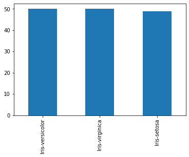

```python
print(df_iris['Species'].value_counts())
df_iris['Species'].value_counts().plot(kind='bar')
```

Method `pandas.DataFrame.info()` prints information about a DataFrame including the index dtype and columns, non-null values, and memory usage. See https://pandas.pydata.org/docs/reference/api/pandas.DataFrame.info.html.

```python
df_iris.info()
```

```
<class 'pandas.core.frame.DataFrame'>
RangeIndex: 149 entries, 0 to 148
Data columns (total 5 columns):
 #   Column        Non-Null Count  Dtype
---  ------        --------------  -----
 0   Sepal Length  149 non-null    float64
 1   Sepal Width   149 non-null    float64
 2   Petal Length  149 non-null    float64
 3   Petal Width   149 non-null    float64
 4   Species       149 non-null    object
dtypes: float64(4), object(1)
memory usage: 5.9+ KB
```

Method `pandas.DataFrame.describe()` generates descriptive statistics. These include central tendency, dispersion, and shape of a dataset's distribution, excluding NaN values. See https://pandas.pydata.org/docs/reference/api/pandas.DataFrame.describe.html#pandas.DataFrame.describe

```python
df_iris.describe()
```

|  | Sepal Length | Sepal Width | Petal Length | Petal Width |
| --- | --- | --- | --- | --- |
| count | 149.000000 | 149.000000 | 149.000000 | 149.000000 |
| mean | 5.848322 | 3.051007 | 3.774497 | 1.205369 |
| std | 0.828594 | 0.433499 | 1.759651 | 0.761292 |
| min | 4.300000 | 2.000000 | 1.000000 | 0.100000 |
| 25% | 5.100000 | 2.800000 | 1.600000 | 0.300000 |
| 50% | 5.800000 | 3.000000 | 4.400000 | 1.300000 |
| 75% | 6.400000 | 3.300000 | 5.100000 | 1.800000 |
| max | 7.900000 | 4.400000 | 6.900000 | 2.500000 |

## Step 2: Analysing and visualising the data

Analyse the dataset using a box-and-whisker plot generated by method `pandas.DataFrame.boxplot()`. See https://pandas.pydata.org/docs/reference/api/pandas.DataFrame.boxplot.html

For more information on box plots, see https://en.wikipedia.org/wiki/Box_plot

From the box plot below, it can be observed that for Sepal Length and Sepal Width, there is some overlap in values for the three different species. Petal Length and Petal Width show less overlap. This information may be useful when selecting features.

**Note**: by default, the box plot will be partly shown and a scroll bar appears. To view the entire box plot, select Cell → All Output → Toggle Scrolling.

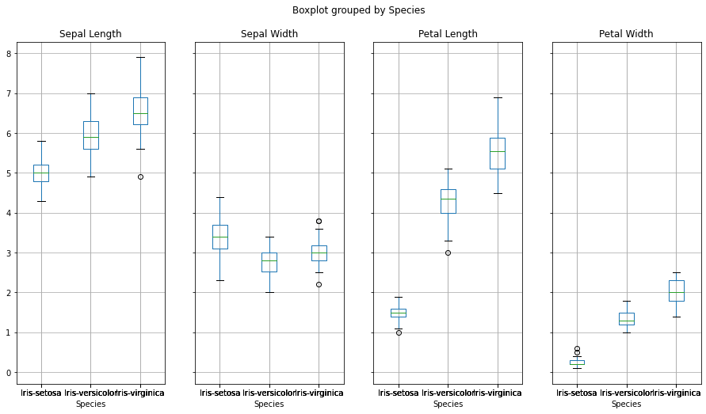

```python
iris_features = tuple(df_iris.columns[:4].values)
df_iris.boxplot(column=iris_features, by='Species', figsize=(15,8), layout=(1,4));
```

Plot pairwise relationships using method `seaborn.pairplot`. See https://seaborn.pydata.org/generated/seaborn.pairplot.html

```
<function matplotlib.pyplot.show(close=None, block=None)>
```

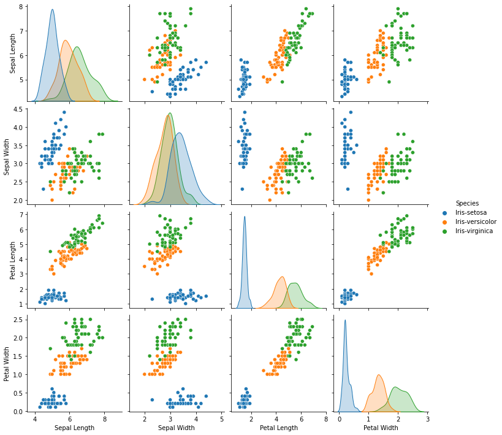

```python
plt.figure(figsize=(8,8))
ax = sns.pairplot(df_iris, hue='Species')
plt.show
```

## Step 3: Cleaning the data

There is no need to clean the data.

## Step 4: Selecting the features

Use all 4 features for clustering. From the box plots it can be observed that the values range between 0 and 8 cm and that the distribution differs per feature. For instance, Sepal Length ranges between 4 and 8 cm, while Petal Width ranges between 0 and 3 cm. When applying K-means clustering it is important to normalize the data. Using the `StandardScaler`, the standard score of a sample $x$ is calculated as $z=(x-u)/s$, where $u$ is the mean and $s$ is the standard deviation.

```python
from sklearn.preprocessing import StandardScaler

# Define X_iris and y_iris

# Use this line to select all four features
X_iris = df_iris[['Sepal Length', 'Sepal Width', 'Petal Length', 'Petal Width']]

# Use this line to select Sepal Length and Sepal Width
# X_iris = df_iris[['Sepal Length', 'Sepal Width']]

# Use this line to select Petal Length and Petal Width
#X_iris = df_iris[['Petal Length', 'Petal Width']]

# Note that we will not use y_iris during clustering
y_iris = df_iris['Species']
print('Iris types:', y_iris.unique())

# Normalize the data
scaler_iris = StandardScaler().fit(X_iris)
X_iris_normalized = scaler_iris.transform(X_iris)
print('The length of X_iris_normalized: ', len(X_iris))
```

```
Iris types: ['Iris-setosa' 'Iris-versicolor' 'Iris-virginica']
The length of X_iris_normalized:  149
```

Visualize the distribution of the data per feature after normalization.

```
Number of selected features:  4
```

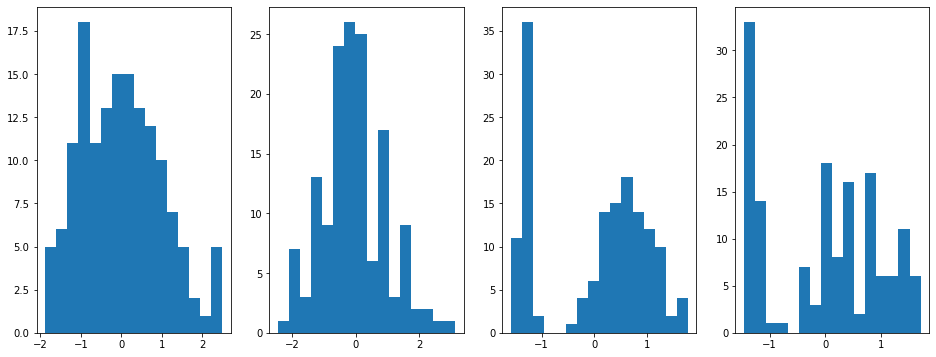

```python
# Define number of bins for histogram
nbins = 16

# Number of selected features
nfeatures = len(X_iris.columns)
print('Number of selected features: ',nfeatures)

# Plot histograms for each of the selected features
fig, axs = plt.subplots(1,nfeatures,figsize=(nfeatures*4,6))
for f in range(nfeatures):
    axs[f].hist(X_iris_normalized[:,f],nbins)
```

## Step 5: Training your machine learning algorithm

To perform hierarchical clustering, we use `sklearn.cluster.AgglomerativeClustering`.

See https://scikit-learn.org/stable/modules/generated/sklearn.cluster.AgglomerativeClustering.html

```python
from sklearn.cluster import AgglomerativeClustering

# Define number of clusters by setting distance threshold
agglom = AgglomerativeClustering(distance_threshold=10, n_clusters=None)

# Use this line for agglomerative clustering using normalized data
agglom.fit(X_iris_normalized)

# Use this line for agglomerative clustering with original data (not normalized)
# agglom.fit(X_iris)
```

```
AgglomerativeClustering(distance_threshold=10, n_clusters=None)
```

Number of clusters found by the algorithm. If parameter `distance_threshold=None`, it will be equal to the given `n_clusters`.

```python
print('Number of clusters: ',agglom.n_clusters_)
```

```
Number of clusters:  3
```

Cluster labels are stored in an ndarray of shape (n_samples).

```python
print(np.unique(agglom.labels_))
```

```
[0 1 2]
```

Number of leaves in the hierarchical tree.

```python
print(agglom.n_leaves_)
```

```
149
```

```python
print(agglom.distances_)
```

```
[ 0.          0.          0.          0.1210934   0.1210934   0.13179866
  0.133847    0.133847    0.133847    0.14360464  0.14360464  0.16634074
  0.16634074  0.17106334  0.17883773  0.18784543  0.21222659  0.21222659
  0.21222659  0.21594803  0.21983185  0.22808446  0.22808446  0.23006272
  0.23837939  0.24218679  0.24218679  0.25802898  0.261222    0.261222
  0.26359732  0.26661938  0.26737304  0.26737304  0.26923793  0.27525681
  0.27731974  0.28654714  0.28720929  0.28974099  0.29563248  0.29809265
  0.30381463  0.31402779  0.31402779  0.31402779  0.31402779  0.31535711
  0.32437475  0.33754406  0.33982227  0.34635798  0.34678051  0.37408506
  0.37408506  0.38517326  0.39135745  0.39294689  0.39303108  0.39673751
  0.40459672  0.40673375  0.41568953  0.42034492  0.42896062  0.43177343
  0.43604936  0.45405739  0.46087077  0.46178931  0.46760956  0.46776522
  0.46798041  0.47535367  0.47732854  0.48452728  0.48481915  0.4866332
  0.49514445  0.50072387  0.51058149  0.51661289  0.53026935  0.53266601
  0.53655983  0.53958571  0.54349616  0.54477745  0.55676387  0.5724536
  0.57306807  0.58763125  0.61549934  0.61938429  0.63154903  0.64084298
  0.67237037  0.69193185  0.70832325  0.71523912  0.74770609  0.758826
  0.80408061  0.80573184  0.8190785   0.84431839  0.85232543  0.86886913
  0.87104326  0.9029098   0.91202588  0.93169633  0.93399525  0.956818
  0.96179925  1.05452316  1.05869781  1.10734884  1.12545325  1.15436084
  1.18922045  1.20330571  1.30042856  1.33812322  1.37560967  1.38152257
  1.43419725  1.43545836  1.53727777  1.65635405  1.80942989  2.01826307
  2.01906892  2.14090856  2.14587331  2.3092109   2.7024012   2.8748501
  3.4604882   3.82455997  3.94883908  3.96174828  4.23773839  4.25224491
  6.96943107  8.01780356 12.66070429 27.04107958]
```

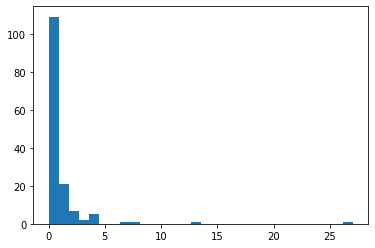

```python
plt.hist(agglom.distances_,30)
```

Plot hierarchical clustering dendrogram.

The code below is adapted from https://scikit-learn.org/stable/auto_examples/cluster/plot_agglomerative_dendrogram.html#sphx-glr-auto-examples-cluster-plot-agglomerative-dendrogram-py

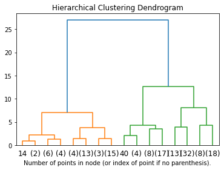

```python
from scipy.cluster.hierarchy import dendrogram

def plot_dendrogram(model, **kwargs):
    # Create linkage matrix and then plot the dendrogram

    # create the counts of samples under each node
    counts = np.zeros(model.children_.shape[0])
    n_samples = len(model.labels_)
    for i, merge in enumerate(model.children_):
        current_count = 0
        for child_idx in merge:
            if child_idx < n_samples:
                current_count += 1  # leaf node
            else:
                current_count += counts[child_idx - n_samples]
        counts[i] = current_count

    linkage_matrix = np.column_stack([model.children_, model.distances_,
                                      counts]).astype(float)

    # Plot the corresponding dendrogram
    dendrogram(linkage_matrix, **kwargs)


plt.title('Hierarchical Clustering Dendrogram')
# plot the top three levels of the dendrogram
plot_dendrogram(agglom, truncate_mode='level', p=3)
plt.xlabel("Number of points in node (or index of point if no parenthesis).")
plt.show()
```

## Step 6: Applying your machine learning algorithm

For each datapoint, add the cluster to the original Iris data set.

```python
df_iris['Cluster'] = agglom.labels_.astype(str)
df_iris['Cluster'] = 'Cluster ' + df_iris['Cluster']
df_iris.head(5)
```

|  | Sepal Length | Sepal Width | Petal Length | Petal Width | Species | Cluster |
| --- | --- | --- | --- | --- | --- | --- |
| 0 | 4.9 | 3.0 | 1.4 | 0.2 | Iris-setosa | Cluster 1 |
| 1 | 4.7 | 3.2 | 1.3 | 0.2 | Iris-setosa | Cluster 1 |
| 2 | 4.6 | 3.1 | 1.5 | 0.2 | Iris-setosa | Cluster 1 |
| 3 | 5.0 | 3.6 | 1.4 | 0.2 | Iris-setosa | Cluster 1 |
| 4 | 5.4 | 3.9 | 1.7 | 0.4 | Iris-setosa | Cluster 1 |

```python
df_iris.tail(5)
```

|  | Sepal Length | Sepal Width | Petal Length | Petal Width | Species | Cluster |
| --- | --- | --- | --- | --- | --- | --- |
| 144 | 6.7 | 3.0 | 5.2 | 2.3 | Iris-virginica | Cluster 0 |
| 145 | 6.3 | 2.5 | 5.0 | 1.9 | Iris-virginica | Cluster 0 |
| 146 | 6.5 | 3.0 | 5.2 | 2.0 | Iris-virginica | Cluster 0 |
| 147 | 6.2 | 3.4 | 5.4 | 2.3 | Iris-virginica | Cluster 0 |
| 148 | 5.9 | 3.0 | 5.1 | 1.8 | Iris-virginica | Cluster 0 |

Plot pairwise relationships per species and per cluster using method `seaborn.pairplot`.

```
<function matplotlib.pyplot.show(close=None, block=None)>
```

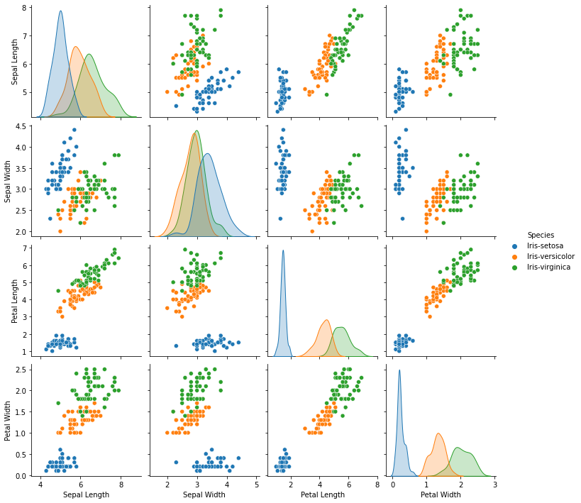

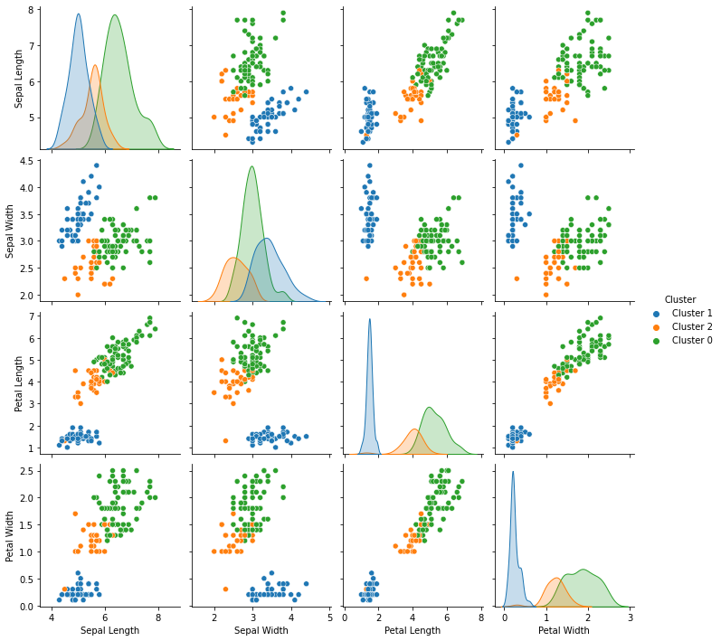

```python
plt.figure(figsize=(8,8))
ax = sns.pairplot(df_iris[["Sepal Length","Sepal Width","Petal Length","Petal Width","Species"]], hue="Species")
plt.show

plt.figure(figsize=(8,8))
ax = sns.pairplot(df_iris[["Sepal Length","Sepal Width","Petal Length","Petal Width","Cluster"]], hue="Cluster")
plt.show
```

## Step 7: Evaluating the results

If clustering is successful, one may expect that flowers of the same species end up in the same cluster. Let us check whether this is the case.

Code for the bar plot is adapted from https://matplotlib.org/stable/gallery/lines_bars_and_markers/barchart.html#sphx-glr-gallery-lines-bars-and-markers-barchart-py

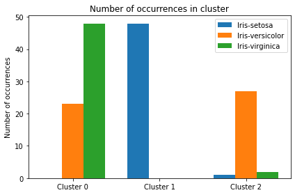

```python
# Define labels for species
species = df_iris['Species'].unique()

# Define labels for clusters
clusters = df_iris['Cluster'].unique()

# Sort cluster names in alphabetical order, i.e.,
# Cluster 0, Cluster 1, Cluster 2, etc.
clusters.sort()

# Determine the location for cluster labels
x = np.arange(len(clusters))

# Define the width of the bars
width = 0.25

# Create the bar plot
fig, ax = plt.subplots()
offset = -width
for spec in species:
    nr_occurrences = []
    for clus in clusters:
        nr = df_iris[(df_iris['Species']==spec) & (df_iris['Cluster']==clus)]['Cluster'].count()
        nr_occurrences.append(nr)
    rects = ax.bar(x + offset, nr_occurrences, width, label=spec)
    offset = offset + width

# Add text for labels, title and custom x-axis tick labels, etc.
ax.set_ylabel('Number of occurrences')
ax.set_title('Number of occurrences in cluster')
ax.set_xticks(x)
ax.set_xticklabels(clusters)
ax.legend()

fig.tight_layout()
plt.show()
```

```python
print(df_iris['Species'].value_counts())
print(df_iris['Cluster'].value_counts())

species = df_iris['Species'].unique()
for spec in species:
    print('Number of samples per cluster for',spec)
    print(df_iris[df_iris['Species']==spec]['Cluster'].value_counts())
```

```
Iris-versicolor    50
Iris-virginica     50
Iris-setosa        49
Name: Species, dtype: int64
Cluster 0    71
Cluster 1    48
Cluster 2    30
Name: Cluster, dtype: int64
Number of samples per cluster for Iris-setosa
Cluster 1    48
Cluster 2     1
Name: Cluster, dtype: int64
Number of samples per cluster for Iris-versicolor
Cluster 2    27
Cluster 0    23
Name: Cluster, dtype: int64
Number of samples per cluster for Iris-virginica
Cluster 0    48
Cluster 2     2
Name: Cluster, dtype: int64
```

## Now it's your turn (A): The effect of normalization before clustering

Change the code in Step 5 such that `X_iris` is used instead of `X_iris_normalized` when applying `AgglomerativeClustering`. Rerun all cells above and compare the results after clustering (Step 6 and Step 7). Note that you should not compare the values of `agglom.distances_`, because the distances change with normalization.

Normalized

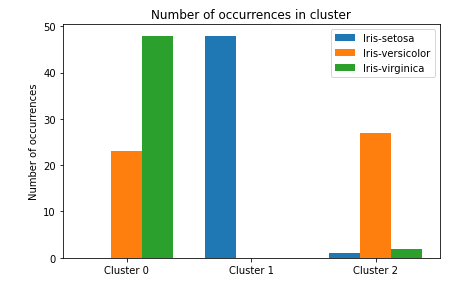

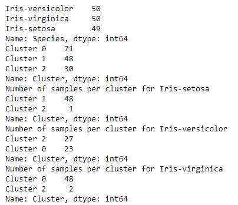

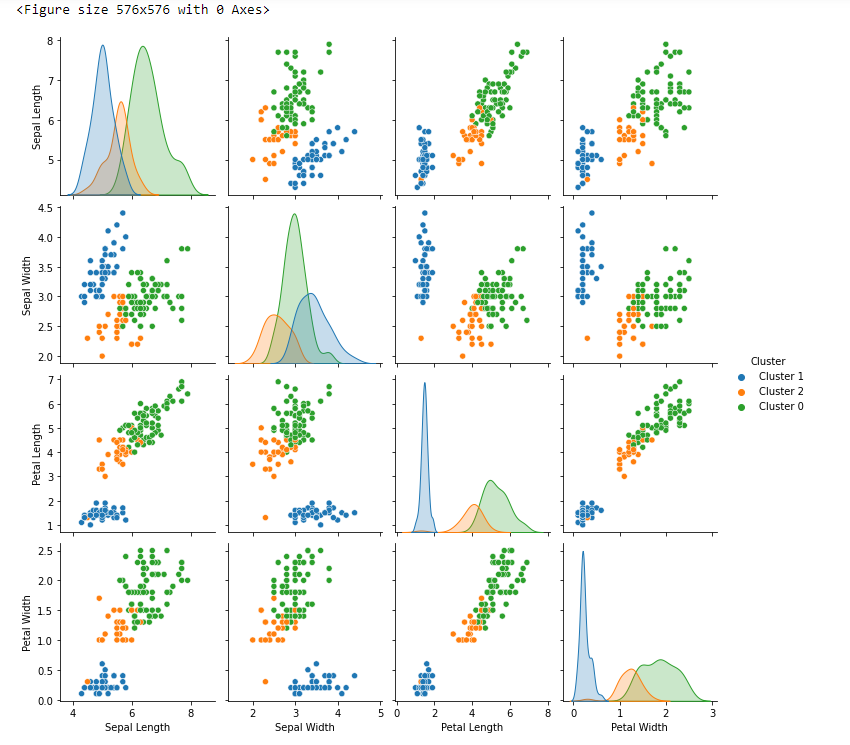

Original

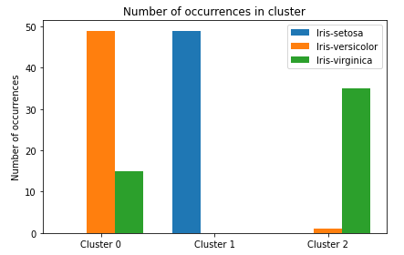

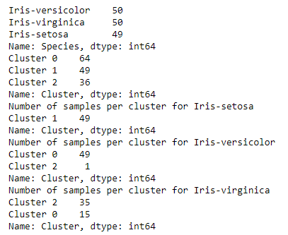

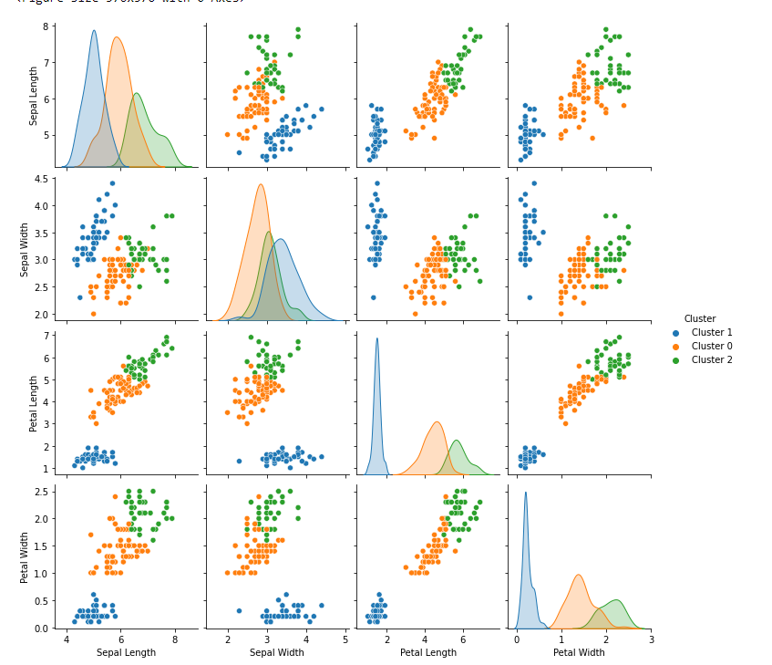

From these results it seems that the none normalized data creates less confusion in the clustering than none normalized, according to this [stackexchange](https://datascience.stackexchange.com/questions/6715/is-it-necessary-to-standardize-your-data-before-clustering) post normalizing data is not always required. The reasoning behind normalizing data is that the distance when clustering matters, so using different scales for the features certain features can weigh in more based on their differences in variance (say a feature goess from 0-100 and one 0-10, the 0-10 feature will have smaller distances).

## Now it's your turn (B): Feature selection (revisited)

Sepal

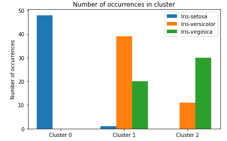

Petal

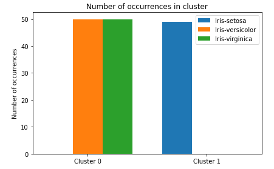

Petal n=3

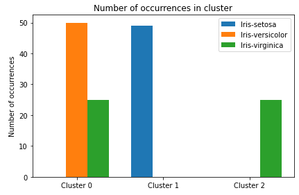

## Now it's your turn (C): K-means clustering

Now apply K-means clustering for the Iris dataset and investigate the effect of normalization and feature selection as described above. Apply the Elbow method to find an optimal value for K.

```python
df = pd.read_csv("http://archive.ics.uci.edu/ml/machine-learning-databases/iris/iris.data")
df.columns = ['Sepal Length', 'Sepal Width', 'Petal Length', 'Petal Width', 'Species']
```

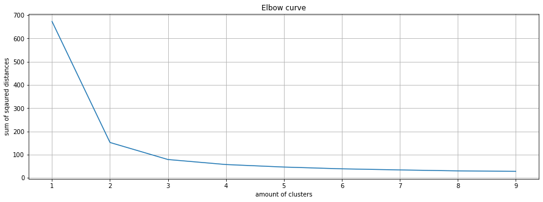

```python
from sklearn.cluster import KMeans

X = df[['Sepal Length', 'Sepal Width', 'Petal Length', 'Petal Width']]

distorsions = []
for k in range(1, 10):
    kmeans = KMeans(n_clusters=k)
    kmeans.fit(X)
    distorsions.append(kmeans.inertia_)

fig = plt.figure(figsize=(15, 5))
plt.plot(range(1, 10), distorsions)
plt.grid(True)
plt.title('Elbow curve')
plt.ylabel('sum of sqaured distances')
plt.xlabel('amount of clusters')
plt.xticks(range(1, 10), range(1, 10));
```

[general sklearn clustering explanation](https://scikit-learn.org/stable/modules/clustering.html)  
[K-means documentation](https://scikit-learn.org/stable/modules/generated/sklearn.cluster.KMeans.html)  
[elbow method with sklearn](https://www.scikit-yb.org/en/latest/api/cluster/elbow.html#:~:text=The%20elbow%20method%20runs%20k,point%20to%20its%20assigned%20center.)  
K-means workes by giving a count of clusters, then the algorithm will assign cluster centers onto the data, then the datapoints closest to the cluster center will be assigned that cluster, after this the cluster center will be repositioned based on the assigned datapoints. These steps can be repeated to create a more precise clustering (might cause overfitting).

[elbow method code](https://stackoverflow.com/questions/41540751/sklearn-kmeans-equivalent-of-elbow-method)  
From the elbow method above can be seen that the difference distorsion decreases significantly after 2 clusters and a lot after 3, using the elbow method this would mean that the elbow would be at either 2 or 3 clusters, seen as the difference between 2 and 3 is still pretty large (and I know it is supposed to be 3 species) I will say that the elbow is at 3 clusters and use this for my K-means.

```python
from sklearn.preprocessing import StandardScaler
df = pd.read_csv("http://archive.ics.uci.edu/ml/machine-learning-databases/iris/iris.data")
df.columns = ['Sepal Length', 'Sepal Width', 'Petal Length', 'Petal Width', 'Species']

y = df['Species']

X = df[['Sepal Length', 'Sepal Width', 'Petal Length', 'Petal Width']]
# X = df[['Sepal Length', 'Sepal Width']]
# X = df[['Petal Length', 'Petal Width']]

scaler = StandardScaler().fit(X)
X = scaler.transform(X)
```

```python
KM = KMeans(n_clusters=3, n_init=10, random_state=0)
#                                    ^ Forgot about random_state for a while creating massive confusion

KM.fit(X)

df['Cluster'] = KM.labels_.astype(str)
df['Cluster'] = 'Cluster ' + df['Cluster']
```

```python
# plt.figure(figsize=(8,8))
# ax = sns.pairplot(df[["Sepal Length","Sepal Width","Petal Length","Petal Width","Species"]], hue="Species")
# plt.show

# plt.figure(figsize=(8,8))
# ax = sns.pairplot(df[["Sepal Length","Sepal Width","Petal Length","Petal Width","Cluster"]], hue="Cluster")
# plt.show
```

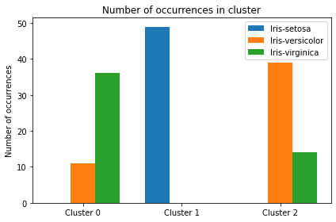

```python
# Define labels for species
species = df['Species'].unique()

# Define labels for clusters
clusters = df['Cluster'].unique()

# Sort cluster names in alphabetical order, i.e.,
# Cluster 0, Cluster 1, Cluster 2, etc.
clusters.sort()

# Determine the location for cluster labels
x = np.arange(len(clusters))

# Define the width of the bars
width = 0.25

# Create the bar plot
fig, ax = plt.subplots()
offset = -width
for spec in species:
    nr_occurrences = []
    for clus in clusters:
        nr = df[(df['Species']==spec) & (df['Cluster']==clus)]['Cluster'].count()
        nr_occurrences.append(nr)
    rects = ax.bar(x + offset, nr_occurrences, width, label=spec)
    offset = offset + width

# Add text for labels, title and custom x-axis tick labels, etc.
ax.set_ylabel('Number of occurrences')
ax.set_title('Number of occurrences in cluster')
ax.set_xticks(x)
ax.set_xticklabels(clusters)
ax.legend()

fig.tight_layout()
plt.show()
```

Normalized

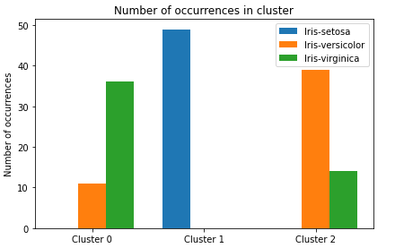

None-Normalized

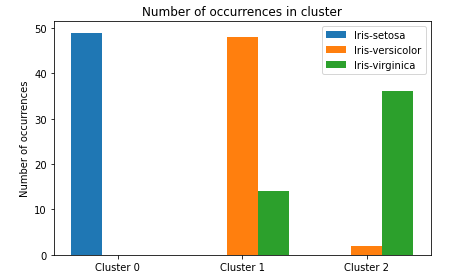

Just as with the hierarchical agglomerative clustering, the none normalized model had less confusion, spicifically with selecting iris-versicolor. I am not completely sure why this is, I think this might be caused by an overfitting of a feature because of the different distances which results in a better clustering here.

I also attempted to use different features, from this my results with none-normalized data stayed the same while with normalized data the clustering seem to be worse. This could indicate that none-normalized clustering indeed has been overfitted, not allowing for any change because of some features that are weight a lot heavier than others.  
I also have a suspicion that maybe I am doing something wrong that is causing these results, making me want to do definitely discuss this with other students and teachers to verify.

After doing some more investigation and finding that I forgot to add normal_state resolving some of my confusion I found a coupel more results, firstly normalized clustering with only petal data seems to be most accurate at clustering the species:

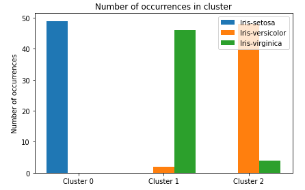

With the normalized varient performing pretty much identical:

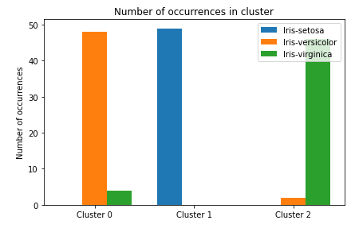